# Analysis of simulated data to test for polygenic selection – GWAS style

Timothy Beissinger

5-12-2016

### Summary

We have been exploring using the sum of allele-frequency-change * allele-substitution-effect in breeding populations as a test for selection on polygenic traits, whether or not individual loci show evidence of a significant association with a trait via selection mapping, GWAS, or QTL mapping. Data-based studies look promising, but to truly evaluate this test statistic we’re exploring simulated data. In this R-markdown file I will load simulation results that involve a selected population with phenotypic data, pre-selection genotypes, and post-selection genotypes. I will perform gwas and calculate allele frequency change over time, then assess whether or not there is significant evidence of polygenic selection.

### Load simulation data

Simulations were performed on the IRCF biocluster using QMSim. GAPIT was run on the IRCF biocluster, so the gapit lines are not evaluated in this run.

```r
directory="r_qtl_200_rnd"

pheno <- read.table(paste(directory, "/Line 1_data_001.txt",sep=""),header=T,stringsAsFactors=F)
map <- read.table(paste(directory, "/lm_mrk_001.txt",sep=""),header=T,stringsAsFactors=F)
geno <- read.table(paste(directory, "/Line 1_mrk_001_head.txt",sep=""),header=F,stringsAsFactors=F,skip=1,sep="", colClasses=c("numeric","character")) # read genos as characters
qtlMap <- read.table(paste(directory, "/lm_qtl_001.txt",sep=""),header=T,stringsAsFactors=F)
```

### Manipulate simulation data

Genotype files are in a strange format. Reorganize by coding to 0,1,2 and so that markers are columns, individuals are rows.

```r
gen <- matrix(NA,nrow=nrow(map),ncol=nrow(geno))
gen <- as.data.frame(gen)
names(gen) <- geno[,1]
for(i in 1:1000){
  #print(i)
  tmp <- as.numeric(unlist(strsplit(geno[i,2],split="")))
  tmp[which(tmp == 3 | tmp ==4)] <- 1
  #tmp[which(tmp==4)] <- 2
  gen[,i] <- tmp
}
gen<-t(gen)
storage.mode(gen)<-"numeric"
geno2 <- cbind(as.numeric(rownames(gen)),gen) #gapit genotype file
rm(gen) # free up memory
rm(geno)
gc()
```

```
##             used  (Mb) gc trigger   (Mb)  max used   (Mb)
## Ncells    396462  21.2     741108   39.6    502920   26.9
## Vcells 101281848 772.8  329601087 2514.7 313819733 2394.3
```

```r
names(geno2) <- c("taxa",map$ID)
```

### GAPIT

At this point, we’ll load GAPIT and use it to do the GWAS.

```r
library(compiler)
library(MASS)
source("http://www.zzlab.net/GAPIT/emma.txt")
source("http://www.zzlab.net/GAPIT/gapit_functions.txt")
library(multtest)
library('gplots')
library('LDheatmap')
library('genetics')
library(rrBLUP)
library(scatterplot3d)
```

Now we can run GAPIT

```r
  pheno2<- pheno[1:1000,c(1,10)] # GAPIT phenotype file -- only 1000 individuals have genotypes (because I deleted the rest from geno file...)
    setwd("GAPIT")
  result <- GAPIT(Y=pheno2, GD=geno2, GM=map, PCA.total=3)
  setwd("..")
```

Now let’s load in effects estimates.

```r
est <- read.csv("GAPIT/GAPIT..Phen.Df.tValue.StdErr.csv")
effects <- est$effect
```

Next up, we should calculate allele frequencies

```r
freqs0<-read.table(paste(directory, "/Line 1_freq_mrk_001.txt",sep=""),header=T,nrows=length(effects),fill=T,stringsAsFactors=F)
names(freqs0)[4]<- "Allele1"
names(freqs0)[5]<- "Allele2"
freqs0$Allele2[which(substr(freqs0$Allele1,1,1)==2)] <- "2:1.00000" # put this in the spot for the second allele
freqs0$Allele1[which(substr(freqs0$Allele1,1,1)==2)] <- "1:0.00000"
freqs0$Allele2[which(substr(freqs0$Allele1,3,3)==1)] <- "2:0.00000" ##
freqs0$Allele1 <- as.numeric(substr(freqs0$Allele1,3,1000))
freqs0$Allele2 <- as.numeric(substr(freqs0$Allele2,3,1000))

freqs20<-read.table(paste(directory, "/Line 1_freq_mrk_001.txt",sep=""),header=F,skip={4*length(effects)+1},fill=T,stringsAsFactors=F)
names(freqs20)[4]<- "Allele1"
names(freqs20)[5]<- "Allele2"
freqs20$Allele2[which(substr(freqs20$Allele1,1,1)==2)] <- "2:1.00000" # put this in the spot for the second allele
freqs20$Allele1[which(substr(freqs20$Allele1,1,1)==2)] <- "1:0.00000"
freqs20$Allele2[which(substr(freqs20$Allele1,3,3)==1)] <- "2:0.00000"  ##
freqs20$Allele1 <- as.numeric(substr(freqs20$Allele1,3,1000))
freqs20$Allele2 <- as.numeric(substr(freqs20$Allele2,3,1000))
```

## Excitement! Now we can look at the correlation of change and effect size

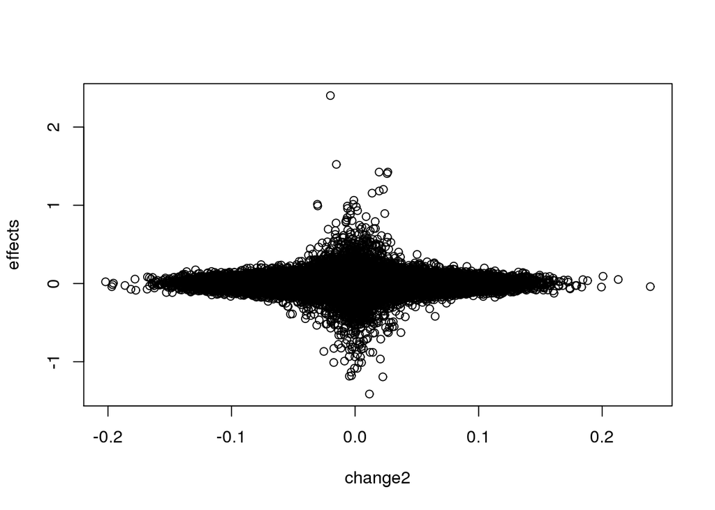

```r
change1<-freqs20$Allele1-freqs0$Allele1
change2<-freqs20$Allele2-freqs0$Allele2

plot(change2,effects)
```

```r
cor.test(change2, effects,use="pairwise.complete.obs")
```

```
##
##  Pearson's product-moment correlation
##
## data:  change2 and effects
## t = -1.9415, df = 99394, p-value = 0.05221
## alternative hypothesis: true correlation is not equal to 0
## 95 percent confidence interval:
##  -1.237427e-02  5.879189e-05
## sample estimates:
##          cor
## -0.006157977
```

## Now we can compute our test statistic, do a permutation test, and make a manhattan plot

```r
# First, compute three statistics of interest
Qstat <- change2 * effects
Qstat_corrected <- abs(change2 * effects)/(freqs0$Allele2*(1-freqs0$Allele2))
Qstat_genome <- sum(change2*effects, na.rm=T)
Qstat_genome
```

```
## [1] -1.984867
```

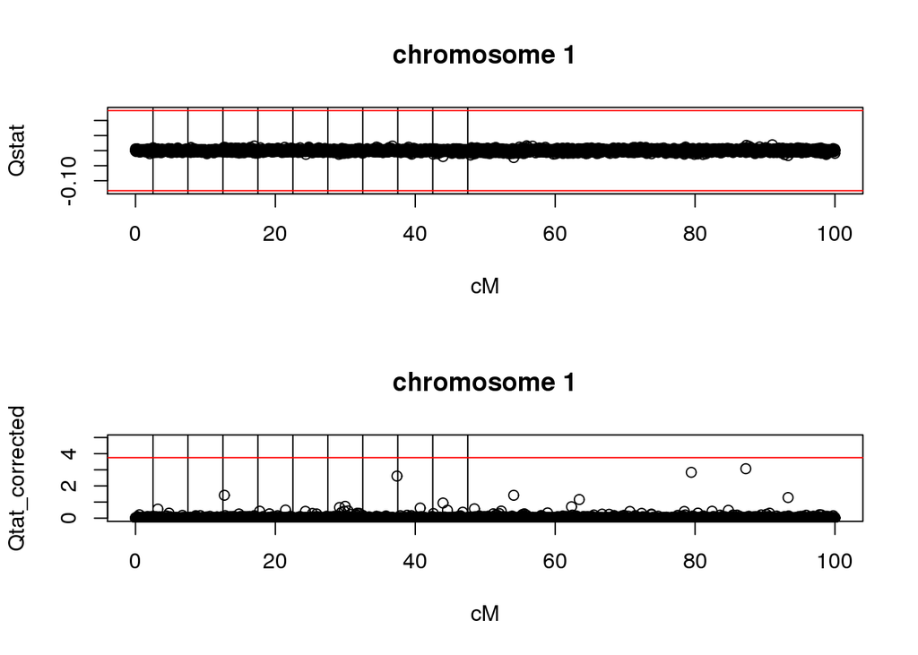

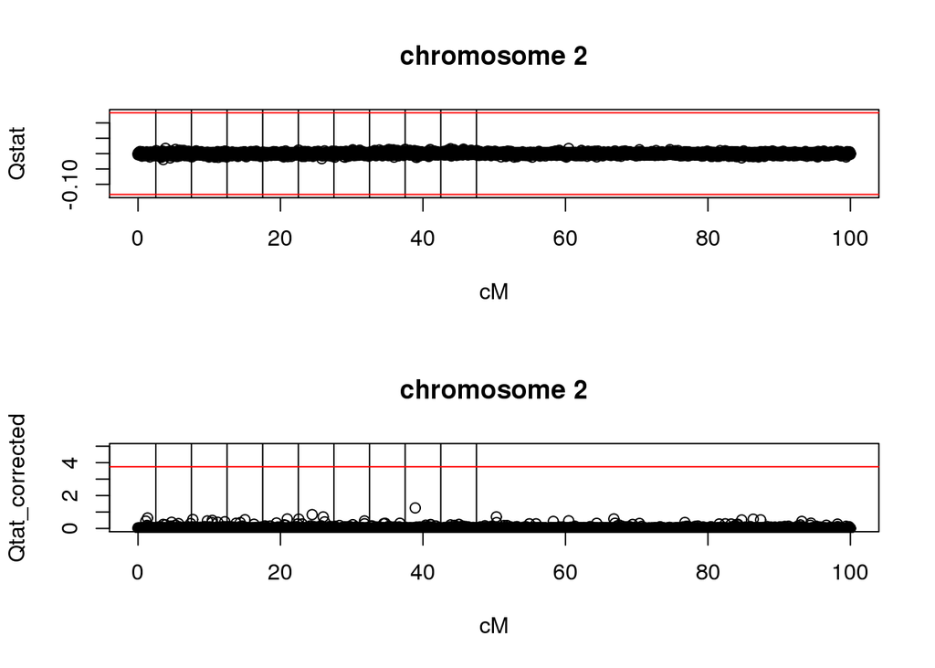

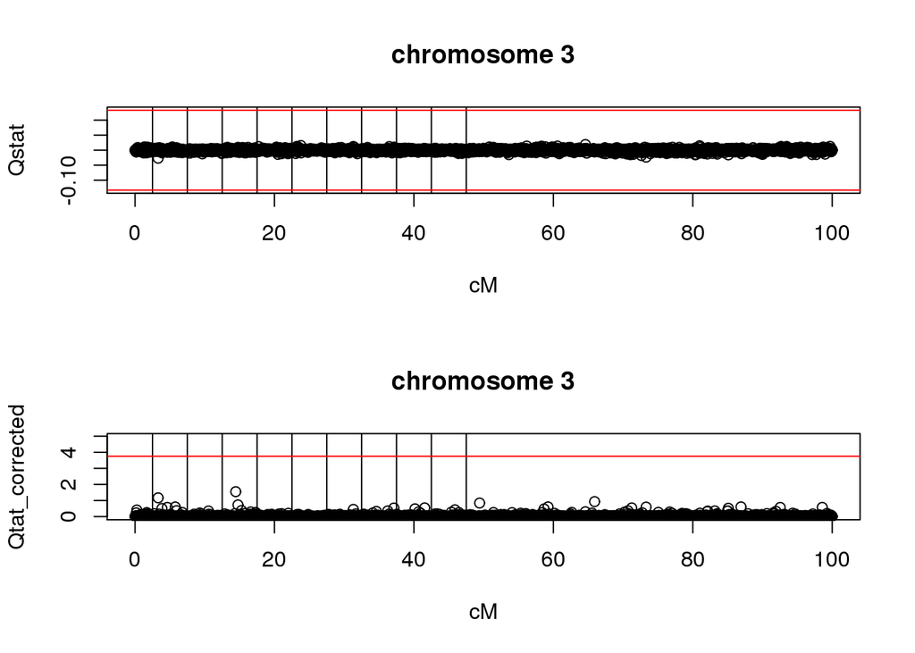

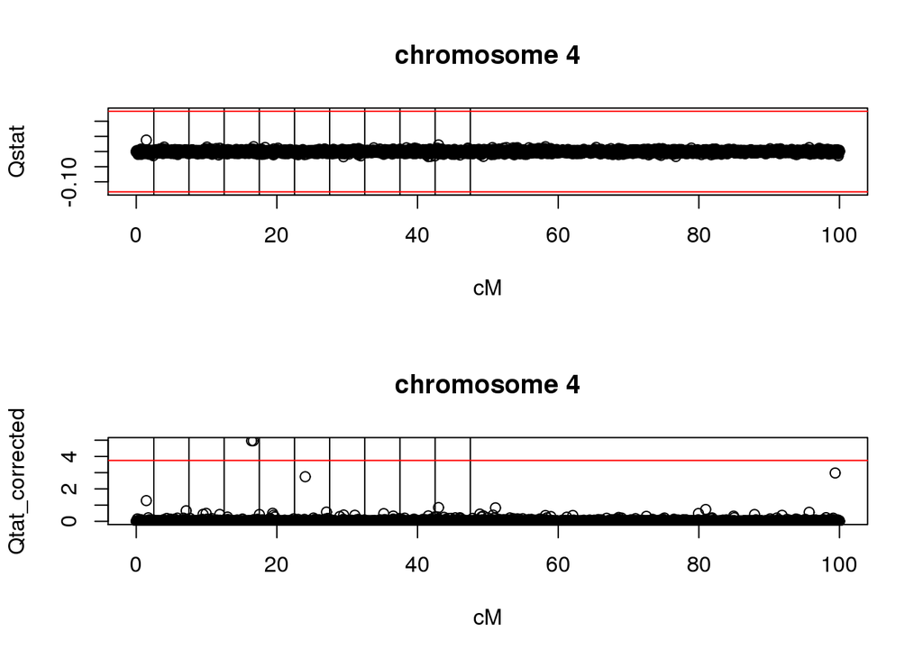

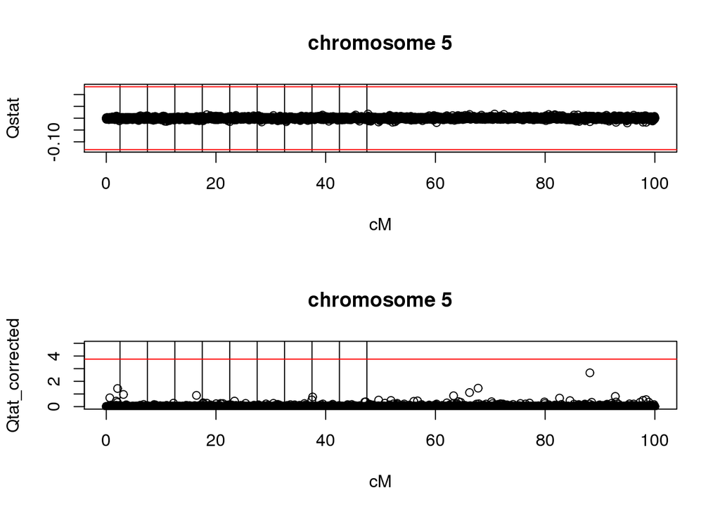

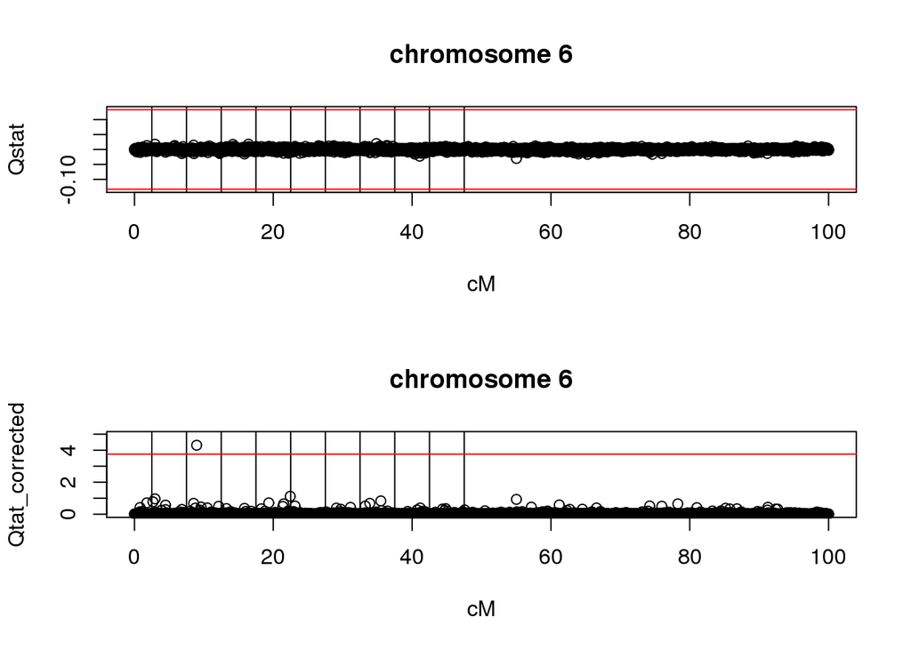

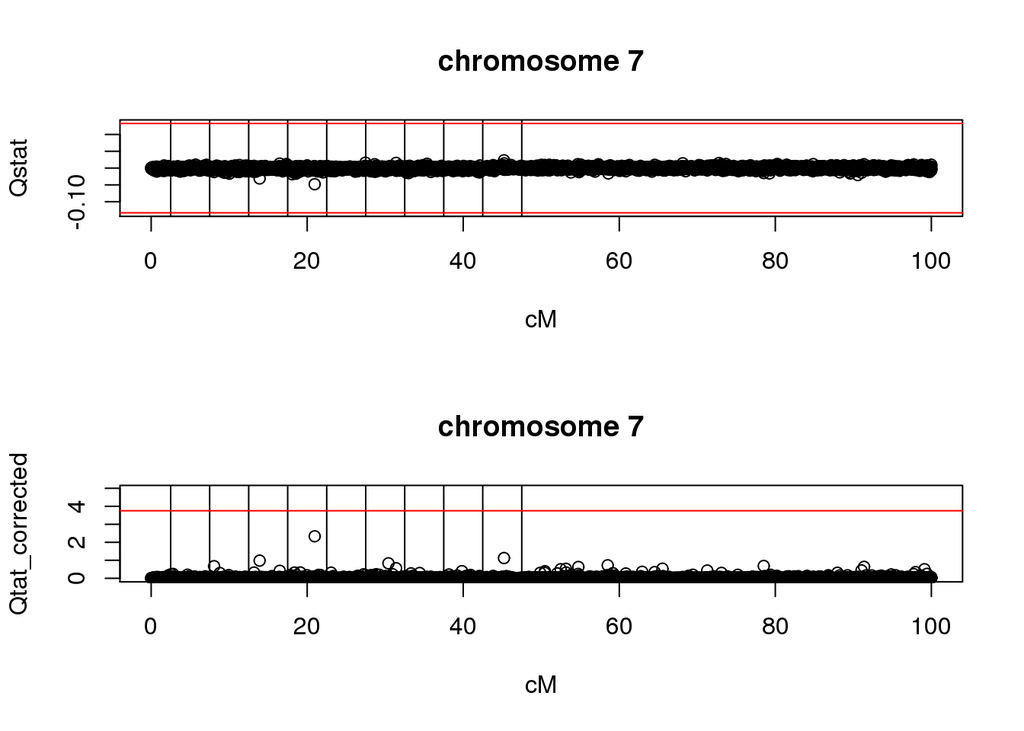

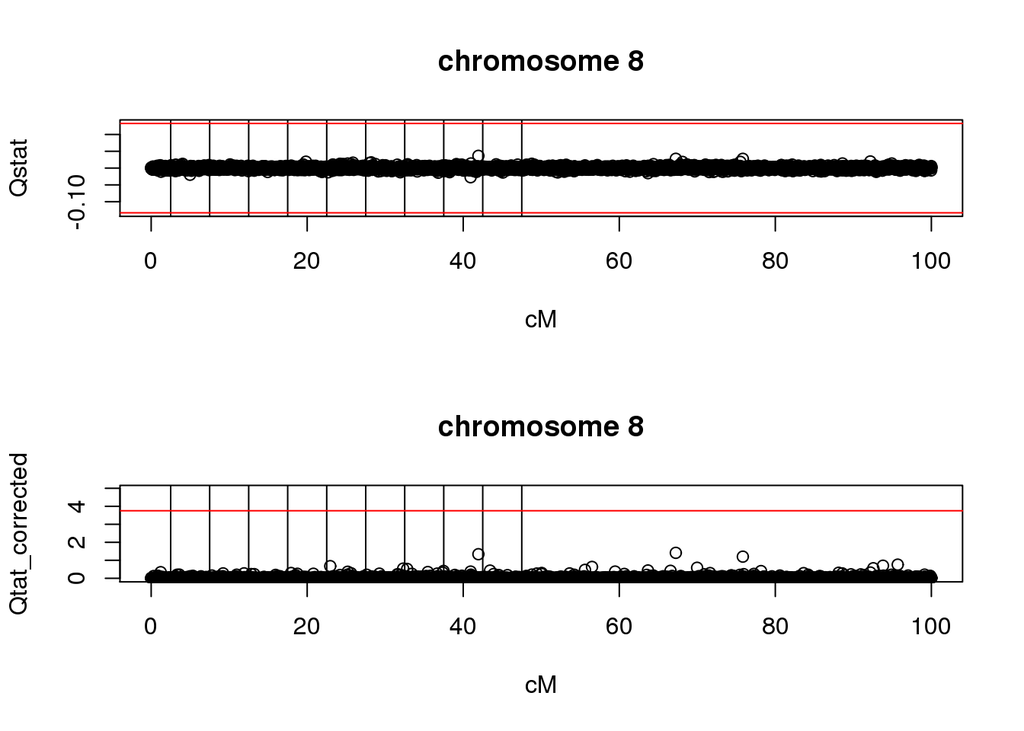

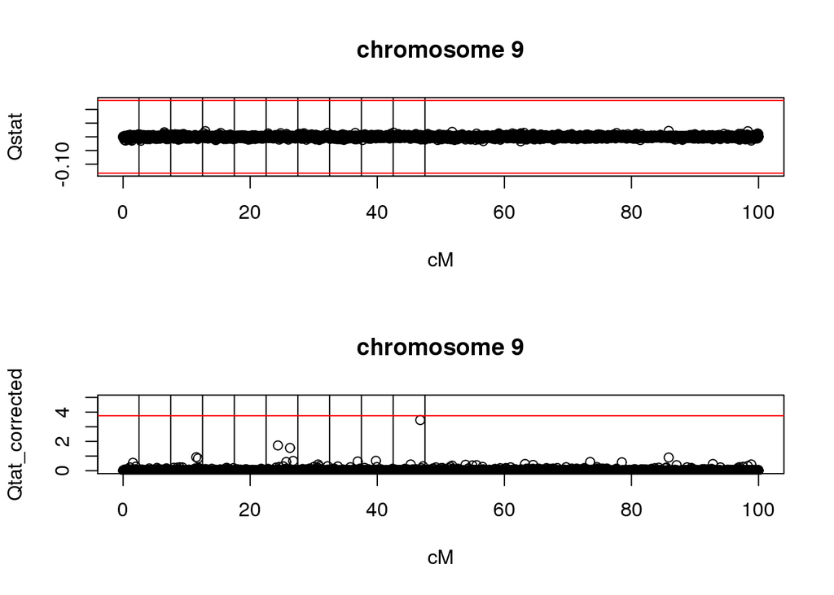

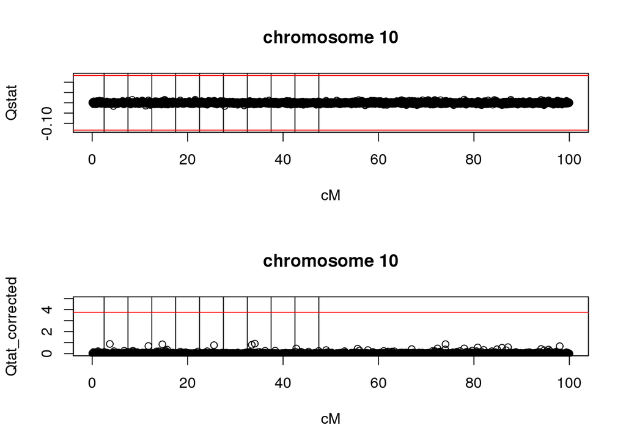

```r
#Qstat_cum <- c(Qstat[1])
#for(i in 2:length(Qstat)){
#  print(i)
#  Qstat_cum[i]<-sum(Qstat[i],Qstat_cum[i-1],na.rm=T)
#  }
#plot(Qstat_cum[1:10000])
#plot(Qstat[1:10000])
#plot(Qstat[10001:20000])
#abline(v=seq(500,99500,1000))

# Now do the permutation test
Qstat_perm_high<-c()
Qstat_perm_low<-c()
Qstat_corrected_perm_high <- c()

Qstat_genome_shuffled <- c()

for(i in 1:1000){
  #print(i)
  change2_index <- sample(length(change2),length(change2),replace=F)
  change2_shuffle <- change2[change2_index]
  freqs0_Allele2_shuffle <- freqs0$Allele2[change2_index]
  effects_shuffle <- sample(effects,length(effects),replace=F)

  Qstat_shuffle <- change2_shuffle*effects_shuffle
  Qstat_corrected_shuffle <- abs(change2_shuffle*effects_shuffle)/(freqs0_Allele2_shuffle *(1-freqs0_Allele2_shuffle))

  Qstat_perm_high[i] <- quantile(Qstat_shuffle,0.99999,na.rm=T)
  Qstat_perm_low[i] <- quantile(Qstat_shuffle,0.00001,na.rm=T)
  Qstat_corrected_perm_high[i] <- quantile(Qstat_corrected_shuffle,0.99999,na.rm=T)

  Qstat_genome_shuffled[i] <- sum(Qstat_shuffle,na.rm=T)
}

Qstat_upper <- quantile(Qstat_perm_high,0.975)
Qstat_lower <- quantile(Qstat_perm_low,0.025)
Qstat_corrected_upper <- quantile(Qstat_corrected_perm_high,0.975)


for(i in 1:10){
start<-i*10000-9999
end<-i*10000
par(mfrow=c(2,1))
plot(map$Position[start:end],Qstat[start:end],ylab="Qstat", xlab="cM",main=paste("chromosome", i),ylim=c(min(Qstat,Qstat_lower,na.rm=T),max(Qstat,Qstat_upper,na.rm=T)))
abline(v=qtlMap$Position[1:10])
abline(h=c(Qstat_upper,Qstat_lower),col="red")

plot(map$Position[start:end],Qstat_corrected[start:end],ylab="Qtat_corrected",xlab="cM",main=paste("chromosome", i),ylim=c(0,max(Qstat_corrected,Qstat_corrected_upper,na.rm=T)))
abline(v=qtlMap$Position[1:10])
abline(h=Qstat_corrected_upper,col="red")
}
```

```r
#Overall data
hist(Qstat_genome_shuffled,xlim=c(min(Qstat_genome,Qstat_genome_shuffled,na.rm=T),max(Qstat_genome,Qstat_genome_shuffled,na.rm=T)))
abline(v=Qstat_genome)

length(which(Qstat>=Qstat_upper | Qstat <= Qstat_lower)) # Number Qstat outliers
```

```
## [1] 0
```

```r
length(which(Qstat_corrected>=Qstat_corrected_upper)) # Number Qstat_corrected outliers
```

```
## [1] 3
```

```r
length(which(abs(Qstat_genome_shuffled) >= abs(Qstat_genome))) / length(Qstat_genome_shuffled) # Qstat_genome p-value
```

```
## [1] 0.053
```

[figure not shown]